# Implementasi Multinomial Logistic Regression menggunakan data Wine

Nuraisi Maba Alhuda – 23031554054

Akhmad Dany – 23031554234

Moh Annas Shobari – 23031554241

Rizki Wahyu Widodo – 23031554242

2025-04-29

# Pendahuluan

### Dokumen ini membahas implementasi dan interpresentasi dari model Multinomial Logistic Regression. Data yang digunakan adalah Data Wine yang di dapat dari situs UCI Meshine Learning Repository. Data Wine merupakan data dari hasil analisis kimia anggur yang ditanam di wilayah yang sama di Italia tetapi berasal dari tiga kultivar yang berbeda. Analisis tersebut menentukan jumlah 13 unsur yang ditemukan di masing-masing dari tiga jenis anggur.

#### Anda dapat mengunduh dataset [di sini](https://archive.ics.uci.edu/dataset/109/wine).

# Import Library yang di gunakan

```r
library(tidyverse)
library(nnet)
library(broom)
library(kableExtra)
library(marginaleffects)
```

```r
library(ggplot2)
library(car)
library(corrplot)
library(caret)
```

# Load Data

```r
data_wine <- read.csv("C:/Users/lenovo/OneDrive/Documents/SEMESTER 4/Analisis Multivariat/P11/Terbaru/whine.csv", header = TRUE, check.names = TRUE)
head(data_wine)
```

```
##   Alcohol Malicacid  Ash Alcalinity_of_ash Magnesium Total_phenols Flavanoids
## 1   14.23      1.71 2.43              15.6       127          2.80       3.06
## 2   13.20      1.78 2.14              11.2       100          2.65       2.76
## 3   13.16      2.36 2.67              18.6       101          2.80       3.24
## 4   14.37      1.95 2.50              16.8       113          3.85       3.49
## 5   13.24      2.59 2.87              21.0       118          2.80       2.69
## 6   14.20      1.76 2.45              15.2       112          3.27       3.39
##   Nonflavanoid_phenols Proanthocyanins Color_intensity  Hue
## 1                 0.28            2.29            5.64 1.04
## 2                 0.26            1.28            4.38 1.05
## 3                 0.30            2.81            5.68 1.03
## 4                 0.24            2.18            7.80 0.86
## 5                 0.39            1.82            4.32 1.04
## 6                 0.34            1.97            6.75 1.05
##   X0D280_0D315_of_diluted_wines Proline class
## 1                          3.92    1065     1
## 2                          3.40    1050     1
## 3                          3.17    1185     1
## 4                          3.45    1480     1
## 5                          2.93     735     1
## 6                          2.85    1450     1
```

# **=========== PREPROCESSING ============**

## Pastikan target menjadi faktor

```r
data_wine$class <- factor(data_wine$class)
```

# **1. Hapus missing value kalau ada**

```r
data_wine <- na.omit(data_wine)
```

## Cek struktur data

```r
str(data_wine)
```

```
## 'data.frame':    178 obs. of  14 variables:
##  $ Alcohol                      : num  14.2 13.2 13.2 14.4 13.2 ...
##  $ Malicacid                    : num  1.71 1.78 2.36 1.95 2.59 1.76 1.87 2.15 1.64 1.35 ...
##  $ Ash                          : num  2.43 2.14 2.67 2.5 2.87 2.45 2.45 2.61 2.17 2.27 ...
##  $ Alcalinity_of_ash            : num  15.6 11.2 18.6 16.8 21 15.2 14.6 17.6 14 16 ...
##  $ Magnesium                    : int  127 100 101 113 118 112 96 121 97 98 ...
##  $ Total_phenols                : num  2.8 2.65 2.8 3.85 2.8 3.27 2.5 2.6 2.8 2.98 ...
##  $ Flavanoids                   : num  3.06 2.76 3.24 3.49 2.69 3.39 2.52 2.51 2.98 3.15 ...
##  $ Nonflavanoid_phenols         : num  0.28 0.26 0.3 0.24 0.39 0.34 0.3 0.31 0.29 0.22 ...
##  $ Proanthocyanins              : num  2.29 1.28 2.81 2.18 1.82 1.97 1.98 1.25 1.98 1.85 ...
##  $ Color_intensity              : num  5.64 4.38 5.68 7.8 4.32 6.75 5.25 5.05 5.2 7.22 ...
##  $ Hue                          : num  1.04 1.05 1.03 0.86 1.04 1.05 1.02 1.06 1.08 1.01 ...
##  $ X0D280_0D315_of_diluted_wines: num  3.92 3.4 3.17 3.45 2.93 2.85 3.58 3.58 2.85 3.55 ...
##  $ Proline                      : int  1065 1050 1185 1480 735 1450 1290 1295 1045 1045 ...
##  $ class                        : Factor w/ 3 levels "1","2","3": 1 1 1 1 1 1 1 1 1 1 ...
```

```r
levels(data_wine$class)
```

```
## [1] "1" "2" "3"
```

# 2. Visualisasi data linieritas

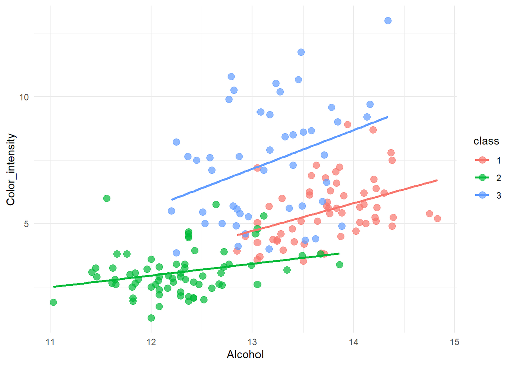

```r
ggplot(data_wine, aes(x = Alcohol, y = Color_intensity, color = class)) +
  geom_point(size = 3, alpha = 0.7) +
  geom_smooth(method = "lm", se = FALSE) +
  theme_minimal()
```

# *3. MENGHANDLE OUTLER*

## 3.1 fungsi deteksi outlier

```r
detect_outliers_zscore <- function(df, threshold = 3) {
  df_numeric <- df %>% select(where(is.numeric))

  if ("class_num" %in% colnames(df_numeric)) {
    df_numeric <- df_numeric %>% select(-class_num)
  }

  z_scores <- scale(df_numeric)
  outlier_flags <- abs(z_scores) > threshold
  outlier_summary <- colSums(outlier_flags, na.rm = TRUE)

  return(outlier_summary)
}
```

## 3.2 hitung/ketahui outlier sebelum penanganan

```r
outliers_before <- detect_outliers_zscore(data_wine)
print(outliers_before)
```

```
##                       Alcohol                     Malicacid
##                             0                             1
##                           Ash             Alcalinity_of_ash
##                             3                             1
##                     Magnesium                 Total_phenols
##                             2                             0
##                    Flavanoids          Nonflavanoid_phenols
##                             1                             0
##               Proanthocyanins               Color_intensity
##                             1                             1
##                           Hue X0D280_0D315_of_diluted_wines
##                             1                             0
##                       Proline
##                             0
```

## 3.3 clipping outlier

### Fungsi clipping

```r
clip_outliers <- function(x, lower_quantile = 0.01, upper_quantile = 0.99) {
  lower <- quantile(x, lower_quantile)
  upper <- quantile(x, upper_quantile)
  x[x < lower] <- lower
  x[x > upper] <- upper
  return(x)
}
```

## 3.4 Fitur yang perlu di-clipping

```r
features_to_clip <- c(
  "Malicacid", "Ash", "Alcalinity_of_ash",
  "Magnesium", "Flavanoids", "Proanthocyanins",
  "Color_intensity", "Hue"
)

data_wine[features_to_clip] <- data_wine[features_to_clip] %>%
  mutate(across(everything(), clip_outliers))
```

## 3.5. HITUNG OUTLIER SETELAH PENANGANAN

```r
outliers_after <- detect_outliers_zscore(data_wine)
print(outliers_after)
```

```
##                       Alcohol                     Malicacid
##                             0                             0
##                           Ash             Alcalinity_of_ash
##                             0                             0
##                     Magnesium                 Total_phenols
##                             2                             0
##                    Flavanoids          Nonflavanoid_phenols
##                             0                             0
##               Proanthocyanins               Color_intensity
##                             0                             0
##                           Hue X0D280_0D315_of_diluted_wines
##                             0                             0
##                       Proline
##                             0
```

## 3.6 TABEL PERBANDINGAN BEFORE vs AFTER

```r
outliers_comparison <- data.frame(
  Feature = names(outliers_before),
  Outliers_Before = as.integer(outliers_before),
  Outliers_After = as.integer(outliers_after[names(outliers_before)])
)
```

## 3.7 Tampilkan tabel

```r
outliers_comparison %>%
  arrange(desc(Outliers_Before)) %>%
  kable("html") %>%
  kable_styling(full_width = FALSE, bootstrap_options = c("striped", "hover", "condensed"))
```

| Feature | Outliers_Before | Outliers_After |
| --- | --- | --- |
| Ash | 3 | 0 |
| Magnesium | 2 | 2 |
| Malicacid | 1 | 0 |
| Alcalinity_of_ash | 1 | 0 |
| Flavanoids | 1 | 0 |
| Proanthocyanins | 1 | 0 |
| Color_intensity | 1 | 0 |
| Hue | 1 | 0 |
| Alcohol | 0 | 0 |
| Total_phenols | 0 | 0 |
| Nonflavanoid_phenols | 0 | 0 |
| X0D280_0D315_of_diluted_wines | 0 | 0 |
| Proline | 0 | 0 |

## 3.8 VISUALISASI BOXPLOT SEBELUM DAN SESUDAH

### Data untuk visualisasi sebelum

```r
data_wine_before <- read.csv("C:/Users/lenovo/OneDrive/Documents/SEMESTER 4/Analisis Multivariat/P11/Terbaru/whine.csv", header = TRUE, check.names = TRUE)
data_wine_before$class <- factor(data_wine_before$class)
data_wine_before <- na.omit(data_wine_before)
```

### Buat 2 boxplot

```r
par(mfrow = c(1, 2))  # 2 plot sejajar
```

### Boxplot sebelum atasi outlier

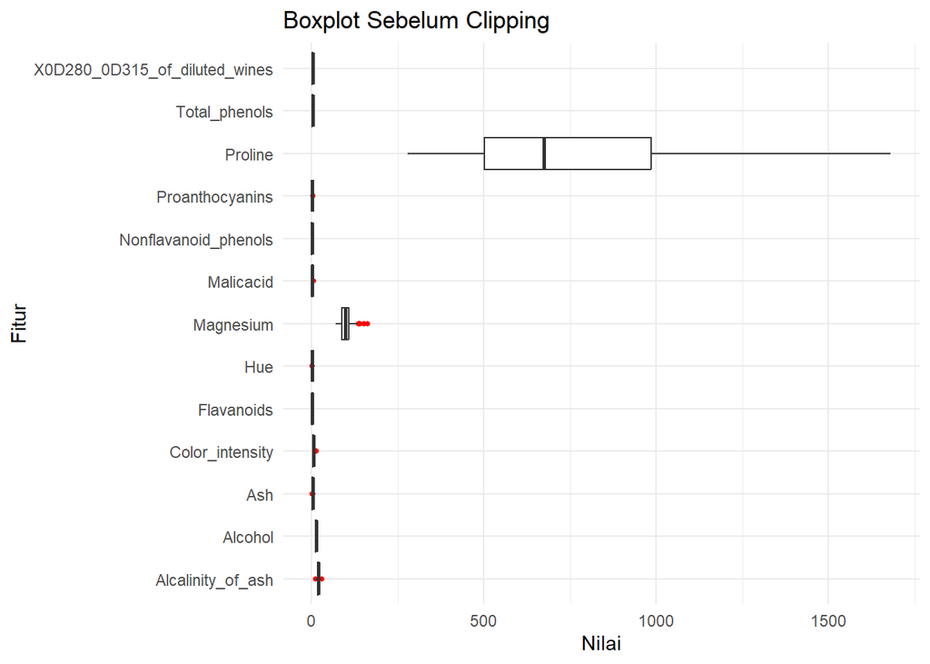

```r
data_wine_before %>%
  select(-class) %>%
  pivot_longer(cols = everything(), names_to = "Fitur", values_to = "Nilai") %>%
  ggplot(aes(x = Fitur, y = Nilai)) +
  geom_boxplot(outlier.color = "red", outlier.size = 1) +
  coord_flip() +
  theme_minimal() +
  labs(title = "Boxplot Sebelum Clipping", x = "Fitur", y = "Nilai")
```

### Boxplot sesudah atasi outlier

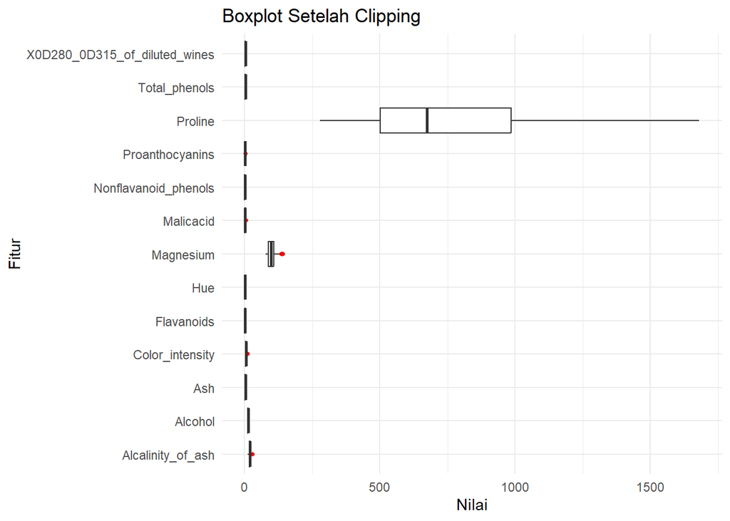

```r
data_wine %>%
  select(-class) %>%
  pivot_longer(cols = everything(), names_to = "Fitur", values_to = "Nilai") %>%
  ggplot(aes(x = Fitur, y = Nilai)) +
  geom_boxplot(outlier.color = "red", outlier.size = 1) +
  coord_flip() +
  theme_minimal() +
  labs(title = "Boxplot Setelah Clipping", x = "Fitur", y = "Nilai")
```

```r
par(mfrow = c(1, 1))  # Reset plot
```

# *4. CEK KORELASI UNTUK MENGETAHUI KORELASI YANG TINGGI*

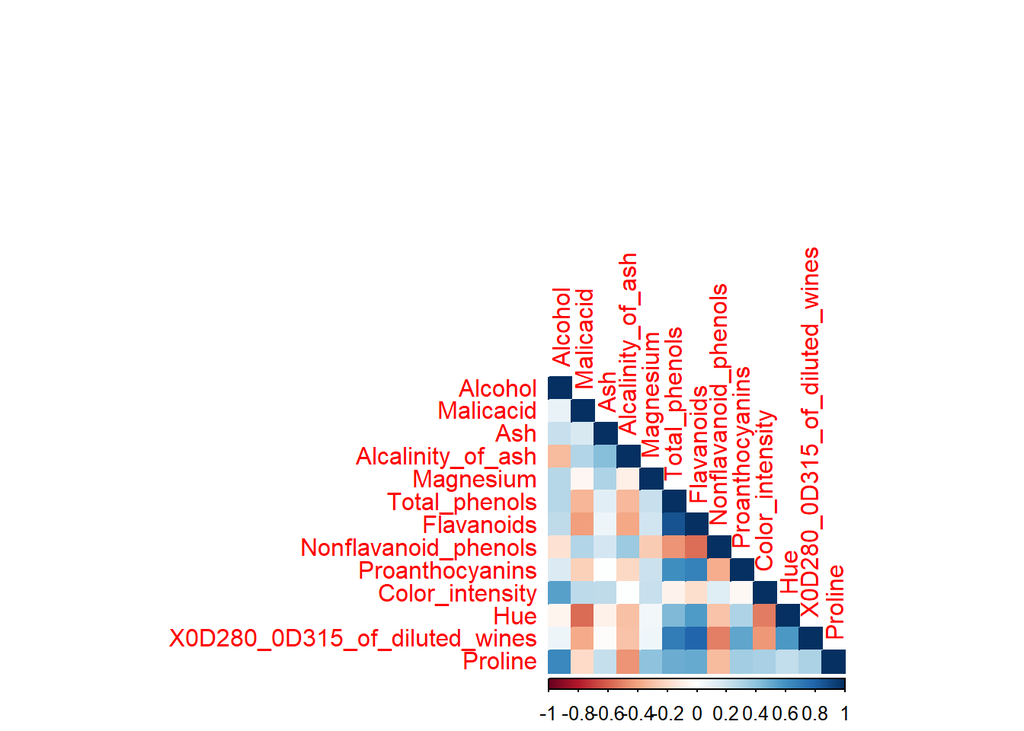

```r
cor_matrix <- cor(select(data_wine, -class))
corrplot::corrplot(cor_matrix, method = "color", type = "lower", tl.cex = 1.0)
```

```r
high_cor_pairs <- which(abs(cor_matrix) > 0.80 & abs(cor_matrix) < 1, arr.ind = TRUE)

if (nrow(high_cor_pairs) > 0) {
  apply(high_cor_pairs, 1, function(idx) {
    cat(rownames(cor_matrix)[idx[1]], "-", colnames(cor_matrix)[idx[2]],
        ": ", cor_matrix[idx[1], idx[2]], "\n")
  })
} else {
  cat("Tidak ada korelasi antar fitur > 0.80\n")
}
```

```
## Flavanoids - Total_phenols :  0.8692106
## Total_phenols - Flavanoids :  0.8692106
```

# Setelah mengetahui korelasi yang tinggi, cek multikolinearitas pakai vif

```r
data_wine$class_num <- as.numeric(data_wine$class)

fit_lm <- lm(class_num ~ . -class, data = data_wine)
vif_values <- car::vif(fit_lm)
print(vif_values)
```

```
##                       Alcohol                     Malicacid
##                      2.432460                      1.658511
##                           Ash             Alcalinity_of_ash
##                      2.072191                      2.212071
##                     Magnesium                 Total_phenols
##                      1.431608                      4.456763
##                    Flavanoids          Nonflavanoid_phenols
##                      7.870950                      1.802629
##               Proanthocyanins               Color_intensity
##                      2.024319                      3.029858
##                           Hue X0D280_0D315_of_diluted_wines
##                      2.633835                      3.735419
##                       Proline
##                      2.870371
```

```r
selected_features <- names(vif_values)[vif_values < 5]
print(selected_features)
```

```
##  [1] "Alcohol"                       "Malicacid"
##  [3] "Ash"                           "Alcalinity_of_ash"
##  [5] "Magnesium"                     "Total_phenols"
##  [7] "Nonflavanoid_phenols"          "Proanthocyanins"
##  [9] "Color_intensity"               "Hue"
## [11] "X0D280_0D315_of_diluted_wines" "Proline"
```

# **===MULTINOMIAL LOGISTIC REGRESSION ===**

# DATA FINAL UNTUK MODELING

```r
data_wine_selected <- data_wine %>%
  select(all_of(selected_features), class)

str(data_wine_selected)
```

```
## 'data.frame':    178 obs. of  13 variables:
##  $ Alcohol                      : num  14.2 13.2 13.2 14.4 13.2 ...
##  $ Malicacid                    : num  1.71 1.78 2.36 1.95 2.59 1.76 1.87 2.15 1.64 1.35 ...
##  $ Ash                          : num  2.43 2.14 2.67 2.5 2.87 2.45 2.45 2.61 2.17 2.27 ...
##  $ Alcalinity_of_ash            : num  15.6 11.4 18.6 16.8 21 ...
##  $ Magnesium                    : num  127 100 101 113 118 112 96 121 97 98 ...
##  $ Total_phenols                : num  2.8 2.65 2.8 3.85 2.8 3.27 2.5 2.6 2.8 2.98 ...
##  $ Nonflavanoid_phenols         : num  0.28 0.26 0.3 0.24 0.39 0.34 0.3 0.31 0.29 0.22 ...
##  $ Proanthocyanins              : num  2.29 1.28 2.81 2.18 1.82 1.97 1.98 1.25 1.98 1.85 ...
##  $ Color_intensity              : num  5.64 4.38 5.68 7.8 4.32 6.75 5.25 5.05 5.2 7.22 ...
##  $ Hue                          : num  1.04 1.05 1.03 0.86 1.04 1.05 1.02 1.06 1.08 1.01 ...
##  $ X0D280_0D315_of_diluted_wines: num  3.92 3.4 3.17 3.45 2.93 2.85 3.58 3.58 2.85 3.55 ...
##  $ Proline                      : int  1065 1050 1185 1480 735 1450 1290 1295 1045 1045 ...
##  $ class                        : Factor w/ 3 levels "1","2","3": 1 1 1 1 1 1 1 1 1 1 ...
```

# FIT MULTINOMIAL LOGISTIC REGRESSION

```r
fit_selected <- multinom(class ~ ., data = data_wine_selected)
```

# INTERPRETASI Relative Log Odds

## Summary log odds interpret

```r
summary(fit_selected)
```

```
## Call:
## multinom(formula = class ~ ., data = data_wine_selected)
##
## Coefficients:
##   (Intercept)   Alcohol Malicacid       Ash Alcalinity_of_ash  Magnesium
## 2   680.19285 -10.68665 -2.608825 -239.9261          13.69161 -0.6113847
## 3   -89.07054  39.54851 15.671327  -66.6167          28.70761 -0.8301563
##   Total_phenols Nonflavanoid_phenols Proanthocyanins Color_intensity       Hue
## 2      35.03611             127.8892        28.31754      -36.424817  359.4479
## 3     138.77755            -279.5729       -70.62997        1.922861 -338.0214
##   X0D280_0D315_of_diluted_wines    Proline
## 2                      -58.2278 -0.4928365
## 3                     -191.2860 -0.1674691
##
## Std. Errors:
##   (Intercept)  Alcohol Malicacid       Ash Alcalinity_of_ash Magnesium
## 2   153.10390 597.3898 236.55809 546.93910         8395.5789 19498.329
## 3    10.02764 150.1122  63.80025  35.43367          208.6994   848.367
##   Total_phenols Nonflavanoid_phenols Proanthocyanins Color_intensity       Hue
## 2    1288.04107            138.64895       261.53165        6.328517 43.023260
## 3      23.15804             13.59585        11.50667       74.163380  3.050656
##   X0D280_0D315_of_diluted_wines   Proline
## 2                    819.895229 2233.9251
## 3                      6.063528  157.9235
##
## Residual Deviance: 3.531451e-08
## AIC: 52
```

## Atau bisa menggunakan keble biar lebih rapi

```r
tidy(fit_selected, conf.int = TRUE) %>%
  kable() %>%
  kable_styling("basic", full_width = FALSE)
```

| y.level | term | estimate | std.error | statistic | p.value | conf.low | conf.high |
| --- | --- | --- | --- | --- | --- | --- | --- |
| 2 | (Intercept) | 680.1928517 | 153.103902 | 4.4426879 | 0.0000089 | 380.11472 | 980.270985 |
| 2 | Alcohol | -10.6866491 | 597.389809 | -0.0178889 | 0.9857275 | -1181.54916 | 1160.175861 |
| 2 | Malicacid | -2.6088247 | 236.558090 | -0.0110283 | 0.9912009 | -466.25416 | 461.036511 |
| 2 | Ash | -239.9261364 | 546.939102 | -0.4386707 | 0.6609002 | -1311.90708 | 832.054805 |
| 2 | Alcalinity_of_ash | 13.6916107 | 8395.578858 | 0.0016308 | 0.9986988 | -16441.34058 | 16468.723802 |
| 2 | Magnesium | -0.6113847 | 19498.328716 | -0.0000314 | 0.9999750 | -38216.63343 | 38215.410657 |
| 2 | Total_phenols | 35.0361072 | 1288.041069 | 0.0272011 | 0.9782994 | -2489.47800 | 2559.550212 |
| 2 | Nonflavanoid_phenols | 127.8892076 | 138.648949 | 0.9223958 | 0.3563222 | -143.85774 | 399.636155 |
| 2 | Proanthocyanins | 28.3175355 | 261.531646 | 0.1082758 | 0.9137770 | -484.27507 | 540.910142 |
| 2 | Color_intensity | -36.4248167 | 6.328517 | -5.7556639 | 0.0000000 | -48.82848 | -24.021151 |
| 2 | Hue | 359.4479054 | 43.023260 | 8.3547342 | 0.0000000 | 275.12386 | 443.771946 |
| 2 | X0D280_0D315_of_diluted_wines | -58.2278044 | 819.895229 | -0.0710186 | 0.9433830 | -1665.19292 | 1548.737316 |
| 2 | Proline | -0.4928365 | 2233.925103 | -0.0002206 | 0.9998240 | -4378.90558 | 4377.919909 |
| 3 | (Intercept) | -89.0705387 | 10.027641 | -8.8825020 | 0.0000000 | -108.72435 | -69.416724 |
| 3 | Alcohol | 39.5485128 | 150.112227 | 0.2634596 | 0.7921963 | -254.66605 | 333.763071 |
| 3 | Malicacid | 15.6713267 | 63.800253 | 0.2456311 | 0.8059678 | -109.37487 | 140.717524 |
| 3 | Ash | -66.6166955 | 35.433673 | -1.8800392 | 0.0601027 | -136.06542 | 2.832028 |
| 3 | Alcalinity_of_ash | 28.7076097 | 208.699404 | 0.1375548 | 0.8905923 | -380.33571 | 437.750926 |
| 3 | Magnesium | -0.8301563 | 848.367025 | -0.0009785 | 0.9992192 | -1663.59897 | 1661.938659 |
| 3 | Total_phenols | 138.7775472 | 23.158038 | 5.9926298 | 0.0000000 | 93.38863 | 184.166467 |
| 3 | Nonflavanoid_phenols | -279.5728528 | 13.595846 | -20.5631086 | 0.0000000 | -306.22022 | -252.925485 |
| 3 | Proanthocyanins | -70.6299744 | 11.506666 | -6.1381792 | 0.0000000 | -93.18262 | -48.077325 |
| 3 | Color_intensity | 1.9228610 | 74.163380 | 0.0259274 | 0.9793153 | -143.43469 | 147.280415 |
| 3 | Hue | -338.0213883 | 3.050656 | -110.8028671 | 0.0000000 | -344.00056 | -332.042213 |
| 3 | X0D280_0D315_of_diluted_wines | -191.2859990 | 6.063528 | -31.5469814 | 0.0000000 | -203.17030 | -179.401703 |
| 3 | Proline | -0.1674691 | 157.923517 | -0.0010604 | 0.9991539 | -309.69187 | 309.356936 |

## **HASIL INTERPRETASI RELATIVE LOG ODDS**

### Relative Log Odds ini mengintrepresentasikan nilai estimate sama p-value. Setiap kenaikan 1 unit pada fitur berikut memberikan perubahan log odds terhadap pilihan kelas dibandingkan dengan Class 1

### *—perbandingan class 2 vs class 1—*

#### Di antara semua fitur tersebut, Hue dan Color_intensity merupakan variabel yang signifikan secara statistik, ditunjukkan oleh nilai p-value sebesar 0.000, yang jauh lebih kecil dari ambang signifikansi 0.05. Hal ini mengimplikasikan bahwa Hue memiliki pengaruh yang kuat dan signifikan dalam membedakan antara kelas 2 dan kelas 1

### *—Perbandingan Class 3 vs Class 1—*

#### Berdasarkan hasil estimasi model regresi logistik multinomial untuk perbandingan antara kelas 3 dan kelas 1, ditemukan bahwa beberapa fitur seperti Alkohol, Malicacid, Alcalinity_of_ash, Total_phenols, Color_intensity memiliki koefisien positif. Ini menunjukkan bahwa peningkatan nilai pada fitur-fitur tersebut cenderung meningkatkan kemungkinan suatu observasi diklasifikasikan ke dalam kelas 3 dibandingkan kelas 1. Sebaliknya, fitur dengan nilai koefisien negatif, yang mengindikasikan adanya penurunan kemungkinan masuk ke dalam kelas 3 seiring peningkatan nilai fitur tersebut.

#### Dari keseluruhan fitur yaitu Total_phenols, Nonflavanoid_phenols, Proanthocyanins, Hue, X0D280_0D315_of_diluted_wines tercatat sebagai satu-satunya variabel yang signifikan secara statistik, dengan nilai p-value sebesar 0.00, yang berada di bawah ambang signifikansi 0.05. Hal ini menunjukkan bahwa fitur tersebut memiliki pengaruh yang kuat dan signifikan dalam membedakan kelas 3 dan kelas 1.

# ———————————————-

# INTERPRETAASI Relative Risk Ration (RRR)

```r
exp(coef(fit_selected))
```

```
##     (Intercept)      Alcohol    Malicacid           Ash Alcalinity_of_ash
## 2 2.535141e+295 2.284795e-05 7.362102e-02 6.329988e-105      8.834683e+05
## 3  2.075662e-39 1.498652e+17 6.396917e+06  1.171485e-29      2.934651e+12
##   Magnesium Total_phenols Nonflavanoid_phenols Proanthocyanins Color_intensity
## 2 0.5425990  1.644326e+15         3.479983e+55    1.986778e+12    1.516712e-16
## 3 0.4359811  1.863472e+60        3.828712e-122    2.117346e-31    6.840501e+00
##            Hue X0D280_0D315_of_diluted_wines   Proline
## 2 1.27715e+156                  5.152119e-26 0.6108911
## 3 1.58189e-147                  8.424540e-84 0.8458027
```

## Atau bisa menggunakan kable untuk RRR

```r
tidy(fit_selected, conf.int = TRUE, exponentiate = TRUE) %>%
  kable() %>%
  kable_styling("basic", full_width = FALSE)
```

| y.level | term | estimate | std.error | statistic | p.value | conf.low | conf.high |
| --- | --- | --- | --- | --- | --- | --- | --- |
| 2 | (Intercept) | 2.535141e+295 | 153.103902 | 4.4426879 | 0.0000089 | 1.207048e+165 | Inf |
| 2 | Alcohol | 2.280000e-05 | 597.389809 | -0.0178889 | 0.9857275 | 0.000000e+00 | Inf |
| 2 | Malicacid | 7.362100e-02 | 236.558090 | -0.0110283 | 0.9912009 | 0.000000e+00 | 1.681174e+200 |
| 2 | Ash | 0.000000e+00 | 546.939102 | -0.4386707 | 0.6609002 | 0.000000e+00 | Inf |
| 2 | Alcalinity_of_ash | 8.834683e+05 | 8395.578858 | 0.0016308 | 0.9986988 | 0.000000e+00 | Inf |
| 2 | Magnesium | 5.425990e-01 | 19498.328716 | -0.0000314 | 0.9999750 | 0.000000e+00 | Inf |
| 2 | Total_phenols | 1.644326e+15 | 1288.041069 | 0.0272011 | 0.9782994 | 0.000000e+00 | Inf |
| 2 | Nonflavanoid_phenols | 3.479983e+55 | 138.648949 | 0.9223958 | 0.3563222 | 0.000000e+00 | 3.628914e+173 |
| 2 | Proanthocyanins | 1.986778e+12 | 261.531646 | 0.1082758 | 0.9137770 | 0.000000e+00 | 8.208993e+234 |
| 2 | Color_intensity | 0.000000e+00 | 6.328517 | -5.7556639 | 0.0000000 | 0.000000e+00 | 0.000000e+00 |
| 2 | Hue | 1.277150e+156 | 43.023260 | 8.3547342 | 0.0000000 | 3.053348e+119 | 5.342042e+192 |
| 2 | X0D280_0D315_of_diluted_wines | 0.000000e+00 | 819.895229 | -0.0710186 | 0.9433830 | 0.000000e+00 | Inf |
| 2 | Proline | 6.108911e-01 | 2233.925103 | -0.0002206 | 0.9998240 | 0.000000e+00 | Inf |
| 3 | (Intercept) | 0.000000e+00 | 10.027641 | -8.8825020 | 0.0000000 | 0.000000e+00 | 0.000000e+00 |
| 3 | Alcohol | 1.498652e+17 | 150.112227 | 0.2634596 | 0.7921963 | 0.000000e+00 | 8.942522e+144 |
| 3 | Malicacid | 6.396917e+06 | 63.800253 | 0.2456311 | 0.8059678 | 0.000000e+00 | 1.296714e+61 |
| 3 | Ash | 0.000000e+00 | 35.433673 | -1.8800392 | 0.0601027 | 0.000000e+00 | 1.697985e+01 |
| 3 | Alcalinity_of_ash | 2.934651e+12 | 208.699404 | 0.1375548 | 0.8905923 | 0.000000e+00 | 1.296616e+190 |
| 3 | Magnesium | 4.359811e-01 | 848.367025 | -0.0009785 | 0.9992192 | 0.000000e+00 | Inf |
| 3 | Total_phenols | 1.863472e+60 | 23.158038 | 5.9926298 | 0.0000000 | 3.615476e+40 | 9.604627e+79 |
| 3 | Nonflavanoid_phenols | 0.000000e+00 | 13.595846 | -20.5631086 | 0.0000000 | 0.000000e+00 | 0.000000e+00 |
| 3 | Proanthocyanins | 0.000000e+00 | 11.506666 | -6.1381792 | 0.0000000 | 0.000000e+00 | 0.000000e+00 |
| 3 | Color_intensity | 6.840501e+00 | 74.163380 | 0.0259274 | 0.9793153 | 0.000000e+00 | 9.184841e+63 |
| 3 | Hue | 0.000000e+00 | 3.050656 | -110.8028671 | 0.0000000 | 0.000000e+00 | 0.000000e+00 |
| 3 | X0D280_0D315_of_diluted_wines | 0.000000e+00 | 6.063528 | -31.5469814 | 0.0000000 | 0.000000e+00 | 0.000000e+00 |
| 3 | Proline | 8.458027e-01 | 157.923517 | -0.0010604 | 0.9991539 | 0.000000e+00 | 2.249106e+134 |

## **HASIL INTERPRETASI Relative Risk Ration (RRR)**

## Hasil eksponensial dari koefisien menunjukkan perubahan rasio peluang memilih kelas dibandingkan dengan Class 1

### —Perbandingan Class 2 vs Class 1—

#### Sebagian besar fitur tidak berpengaruh signifikan dalam membedakan Class 2 dari Class 1 (p-value > 0.05). Namun, terdapat dua fitur yang signifikan:

#### 1. Hue: Secara signifikan meningkatkan risiko memilih Class 2 (p < 0.001).

#### 2. Color Intensity: Secara signifikan menurunkan risiko memilih Class 2 (p < 0.001).

#### Fitur lainnya seperti Alcohol, Malicacid, Ash, Magnesium, dll. tidak berkontribusi secara signifikan terhadap klasifikasi Class 2.

### —Perbandingan Class 3 vs Class 1—

#### Sebagian besar fitur tidak berpengaruh signifikan terhadap klasifikasi ke Class 3. Namun, terdapat beberapa fitur yang menunjukkan pengaruh signifikan (p < 0.001):

#### 1. Total Phenols: Secara signifikan meningkatkan risiko memilih Class 3.

#### 2. Nonflavanoid Phenols, Proanthocyanins, Hue, dan OD280/OD315: Secara signifikan menurunkan risiko memilih Class 3.

#### Fitur Ash hampir signifikan (p = 0.060), sementara fitur lainnya seperti Alcohol, Malicacid, Magnesium, dll. tidak signifikan memberikan pengaruh yang berarti secara statistik.

# —————————-

# PLOT MARGINAL EFFECTS

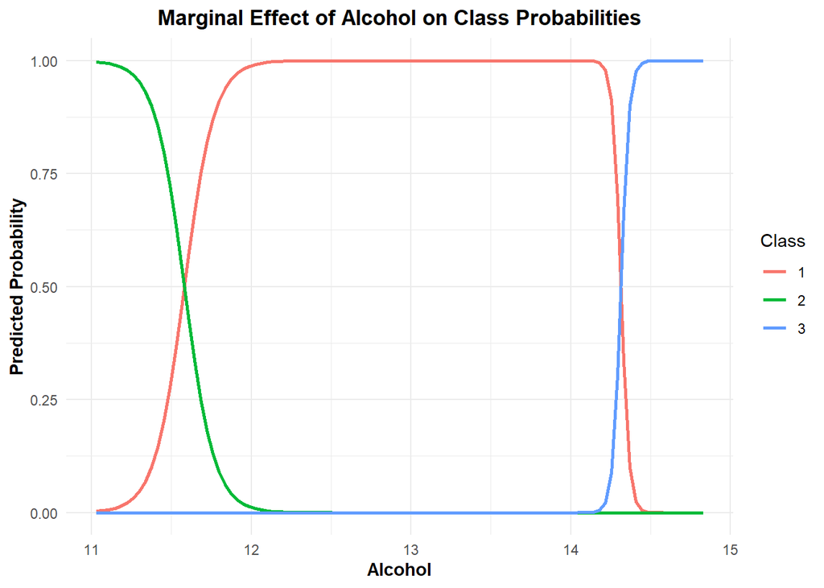

```r
plot_marginal_effect <- function(fit_model, data_selected, variable_name, n_points = 100) {
  variable_range <- seq(
    from = min(data_selected[[variable_name]]),
    to = max(data_selected[[variable_name]]),
    length.out = n_points
  )

  newdata <- data_selected %>%
    select(-class) %>%
    summarise(across(everything(), mean)) %>%
    slice(rep(1, n_points))

  newdata[[variable_name]] <- variable_range

  pred_prob <- predict(fit_model, newdata = newdata, type = "probs")

  plot_data <- cbind(Variable = variable_range, as.data.frame(pred_prob))

  plot_data_long <- pivot_longer(plot_data, cols = -Variable, names_to = "Class", values_to = "Probability")

  ggplot(plot_data_long, aes(x = Variable, y = Probability, color = Class)) +
    geom_line(size = 1) +
    theme_minimal() +
    labs(
      title = paste("Marginal Effect of", variable_name, "on Class Probabilities"),
      x = variable_name,
      y = "Predicted Probability",
      color = "Class"
    ) +
    theme(
      plot.title = element_text(hjust = 0.5, face = "bold"),
      axis.title = element_text(face = "bold")
    )
}
plot_marginal_effect(fit_model = fit_selected, data_selected = data_wine_selected, variable_name = "Alcohol")
```

## **—Hasil Interpretasi Plot Marginal Effect—**

### effects Alcohol terhadap probabilitas masing-masing kelas:

### Class 1 (Merah):

#### - Probabilitas memilih Class 1 meningkat sangat tajam mulai sekitar Alcohol 11.5–12.5, dan hampir pasti (probabilitas mendekati 1) untuk nilai Alcohol 12.5–14.

#### - Namun, setelah Alcohol > 14, probabilitas memilih Class 1 turun sangat drastis hingga mendekati nol.

### Class 2 (hijau)

#### - Probabilitas memilih Class 2 sangat tinggi saat Alcohol berada di bawah 11.5.

#### - Setelah Alcohol > 11.5, probabilitas Class 2 menurun tajam dan hampir nol pada Alcohol > 12.

### Class 3 (biru)

#### - Probabilitas memilih Class 3 tetap hampir nol hingga Alcohol sekitar 14.

# INTERPRETASI Average Marginal Effect

```r
mfx_Alcohol <- avg_comparisons(fit_selected, variables = "Alcohol", type = "probs")
print(mfx_Alcohol)
```

```
##
##  Group Estimate Std. Error         z Pr(>|z|)   S  2.5 % 97.5 %
##      1 -0.00551       19.5 -2.82e-04        1 0.0  -38.3   38.3
##      2 -0.01739      399.9 -4.35e-05        1 0.0 -783.8  783.8
##      3  0.02290      382.5  5.99e-05        1 0.0 -749.7  749.7
##
## Term: Alcohol
## Type:  probs
## Comparison: +1
```

### Hasil interpretasi dari output Average Marginal Effect (AME) untuk variabel Alcohol pada model multinomial logistik:

#### pada class 1 diketahui nilai estimasi -0.00551 dimana setiap kenaikan 1 unit Alcohol menurunkan probabilitas memilih Class 1 sebesar 0.0055 (sekitar 0.55%).

#### pada class 2 di ketahui nilai estimasi -0.01739 dimana setiap kenaikan 1 unit Alcohol juga menurunkan probabilitas memilih Class 2 sebesar 0.0174 (sekitar 1.74%).

#### pada class 3 di ketahu nilai estimasi 0.02290 dimana Sebaliknya, kenaikan 1 unit Alcohol meningkatkan probabilitas memilih Class 3 sebesar 0.0229 (sekitar 2.29%).

# PREDIKSI DAN AKURASI

```r
pred_selected <- predict(fit_selected, newdata = data_wine_selected)
accuracy_selected <- mean(pred_selected == data_wine$class)
cat("Akurasi model:", accuracy_selected, "\n")
```

```
## Akurasi model: 1
```

### Model klasifikasi multinomial logistik yang digunakan menunjukkan performa sangat baik dengan tingkat akurasi sebesar 1 (100%), yang berarti semua data berhasil diprediksi dengan benar ke dalam kelasnya masing-masing (Class 1, 2, atau 3).

```r
pred <- predict(fit_selected, newdata = data_wine_selected)
confusionMatrix(pred, data_wine$class)
```

```
## Confusion Matrix and Statistics
##
##           Reference
## Prediction  1  2  3
##          1 59  0  0
##          2  0 71  0
##          3  0  0 48
##
## Overall Statistics
##
##                Accuracy : 1
##                  95% CI : (0.9795, 1)
##     No Information Rate : 0.3989
##     P-Value [Acc > NIR] : < 2.2e-16
##
##                   Kappa : 1
##
##  Mcnemar's Test P-Value : NA
##
## Statistics by Class:
##
##                      Class: 1 Class: 2 Class: 3
## Sensitivity            1.0000   1.0000   1.0000
## Specificity            1.0000   1.0000   1.0000
## Pos Pred Value         1.0000   1.0000   1.0000
## Neg Pred Value         1.0000   1.0000   1.0000
## Prevalence             0.3315   0.3989   0.2697
## Detection Rate         0.3315   0.3989   0.2697
## Detection Prevalence   0.3315   0.3989   0.2697
## Balanced Accuracy      1.0000   1.0000   1.0000
```

# **REFERENSI**

### https://www.researchgate.net/publication/353211298_Hybrid_Support_Vector_Machine_and_Logistic_Regression_for_Multiclass_Classification_A_Case_Study_on_Wine_Dataset

### https://www.researchgate.net/publication/226336859_The_Brand_Choice_Model_of_Wine_Consumers_A_Multinomial_Logit_Model